# Predicting TikTok Virality

A Comparative Analysis of Audio Features in Trending vs. Popular Spotify Tracks

Kainoa Pajo

2026-03-18

[figure not shown]

# Introduction

## Project Background and Objectives

The rise of short-form video platforms has fundamentally changed the music industry, with TikTok serving as a massive catalyst for song virality. This project aims to identify the underlying audio features that make a song likely to trend on the platform. To explore this, I am using a dataset of popular TikTok tracks from 2022 and comparing them against a control group of general tracks sourced from Spotify. By combining and balancing these datasets, I am able analyze the distinct sonic profiles of viral hits versus non-viral tracks.

The primary goal of this project is to build a machine learning classification model capable of predicting whether a song will go viral on TikTok (is_viral = 1) or not (is_viral = 0). To achieve this, I will analyze various acoustic properties defined by Spotify’s API, such as “danceability” (how suitable a track is for dancing) and “valence” (the musical positiveness delivered by a track). By exploring the data and comparing multiple models, I hope to uncover which specific features are the strongest predictors of modern virality.

## Data Sourcing

The data for this analysis is curated from two distinct sources:

TikTok Data: The tiktok2022.csv dataset, which contains track features for popular songs on the platform. https://www.kaggle.com/datasets/sveta151/tiktok-popular-songs-2022

[figure not shown]

Spotify Data: The spotify.csv dataset, which serves as our general population control group. https://www.kaggle.com/datasets/maharshipandya/-spotify-tracks-dataset

[figure not shown]

## Data Cleaning

```r
# load the data
tiktok_raw <- read_csv("tiktok2022.csv") %>% clean_names()
spotify_raw <- read_csv("spotify.csv") %>% clean_names()
```

```
## ──────────────────────────────────────────────────────── Delimiter: "," chr
## (5): track_id, artists, album_name, track_name, track_genre dbl (15): ...1,
## popularity, duration_ms, danceability, energy, key, loudness... lgl (1):
## explicit
```

```r
# add response variable 'is_viral' to TikTok dataset
tiktok_data <- tiktok_raw %>%
  mutate(is_viral = 1) %>%
  # rename 'artist_name' to 'artists' to match Spotify dataset
  rename(artists = artist_name)

# determine how many rows in TikTok dataset (263)
n_viral <- nrow(tiktok_data)

# prepare control group from the general Spotify dataset
# use most popular tracks (Top 200)
spotify_control <- spotify_raw %>%
  mutate(is_viral = 0) %>%
  # sort by popularity to ensure use of top tracks
  arrange(desc(popularity)) %>%
  select(track_name, artists, danceability, energy, key, loudness,
         mode, speechiness, acousticness, instrumentalness, liveness,
         valence, tempo, duration_ms, time_signature, is_viral) %>%
  # get exact number needed from the top of the popularity charts
  slice_head(n = n_viral)

# make one clean dataset
music_df <- bind_rows(
  # select matching columns from TikTok dataset
  tiktok_data %>% select(any_of(colnames(spotify_control))),
  spotify_control
) %>%
  # convert response variable to a factor for tidymodels
  mutate(is_viral = factor(is_viral, levels = c("1", "0")),
         # convert mode and key to factors
         mode = factor(mode),
         key = factor(key))

# check that final balance is 263 for both
table(music_df$is_viral)
```

```
##
##   1   0
## 263 263
```

## Codebook

Below is a description of all variables referenced in the final combined dataset (music_df) used for this analysis. These features represent the acoustic properties calculated by the Spotify Web API.

track_name: title of the song.

artists: name of the artist(s) who performed the song.

danceability: a measure from 0.0 to 1.0 describing how suitable a track is for dancing based on a combination of musical elements including tempo, rhythm stability, beat strength, and overall regularity.

energy: a measure from 0.0 to 1.0 representing a perceptual measure of intensity and activity. typically, energetic tracks feel fast, loud, and noisy.

key: the estimated overall key of the track (categorical).

loudness: the overall loudness of a track in decibels (dB).

mode: indicates the modality (major or minor) of a track, the type of scale from which its melodic content is derived (categorical).

speechiness: detects the presence of spoken words (lyrics) in a track.

acousticness: a confidence measure from 0.0 to 1.0 of whether the track is acoustic.

instrumentalness: predicts whether a track contains no vocals.

liveness: detects the presence of an audience in the recording.

valence: a measure from 0.0 to 1.0 describing the musical positiveness conveyed by a track. tracks with high valence sound more positive (happy or cheerful), while tracks with low valence sound more negative (sad, depressed, or angry).

tempo: the overall estimated tempo of a track in beats per minute (BPM).

duration_ms: the duration of the track in milliseconds.

time_signature: an estimated overall time signature of a track, organizing the rhythmic flow.

is_viral: the target variable for our models. a factor where 1 indicates the song is from the viral TikTok dataset and 0 indicates it is from the general Spotify control group.

# Exploratory Data Analysis

Before exploring the distributions and relationships of the audio features, let’s first check for missing data in the combined dataset.

```r
# check for missing data
sum(is.na(music_df))
```

```
## [1] 0
```

As the output above shows, there are 0 missing values in the combined dataset. Since the Spotify API returns complete data for these specific features, no data imputation or row dropping is necessary for further analysis.

## Feature Distributions by Virality

To begin this visual exploration, I want to look at how specific continuous variables differ between these viral TikTok tracks and the general Spotify control group.

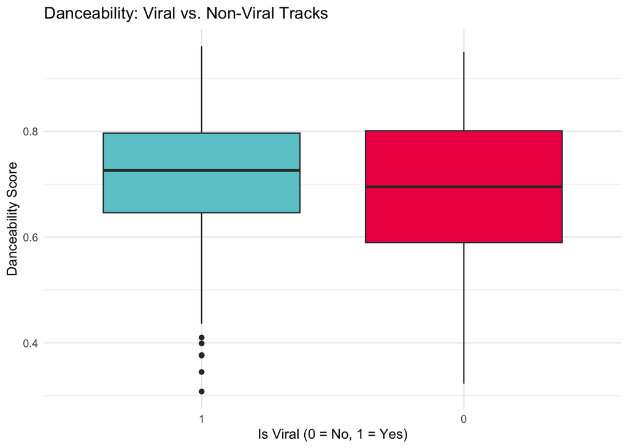

```r
library(ggplot2)

# boxplot for danceability
ggplot(music_df, aes(x = is_viral, y = danceability, fill = is_viral)) +
  geom_boxplot() +
  scale_fill_manual(values = c("0" = "#EE1D52", "1" = "#69C9D0")) +
  labs(title = "Danceability: Viral vs. Non-Viral Tracks",
       x = "Is Viral (0 = No, 1 = Yes)",
       y = "Danceability Score") +
  theme_minimal() +
  theme(legend.position = "none")
```

The boxplot above illustrates the distribution of danceability scores. It does this by observing the median danceability for viral TikTok tracks (1) and comparing it to the non-viral control group (0). Given TikTok’s format as a short-form video platform heavily reliant on dance trends, I expect viral tracks to appear higher in this metric.

Next, I’d like to examine the energy levels using a density plot. This visual highlights where the bulk of the data points fall for both classes. It allows me to determine if viral tracks tend to cluster around high-energy, intense sounds, or if there is a broader spread compared to standard Spotify listening habits.

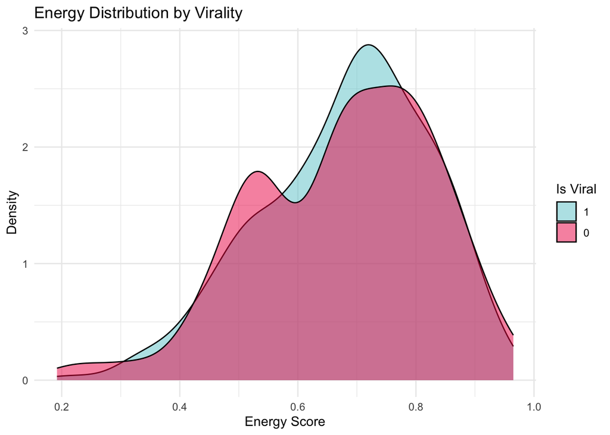

```r
# density plot for energy
ggplot(music_df, aes(x = energy, fill = is_viral)) +
  geom_density(alpha = 0.5) +
  scale_fill_manual(values = c("0" = "#EE1D52", "1" = "#69C9D0")) +
  labs(title = "Energy Distribution by Virality",
       x = "Energy Score",
       y = "Density",
       fill = "Is Viral") +
  theme_minimal()
```

## Categorical Feature Analysis

Next, I’d like to explore the categorical predictors, such as the musical modality (major vs. minor scale) of the tracks.

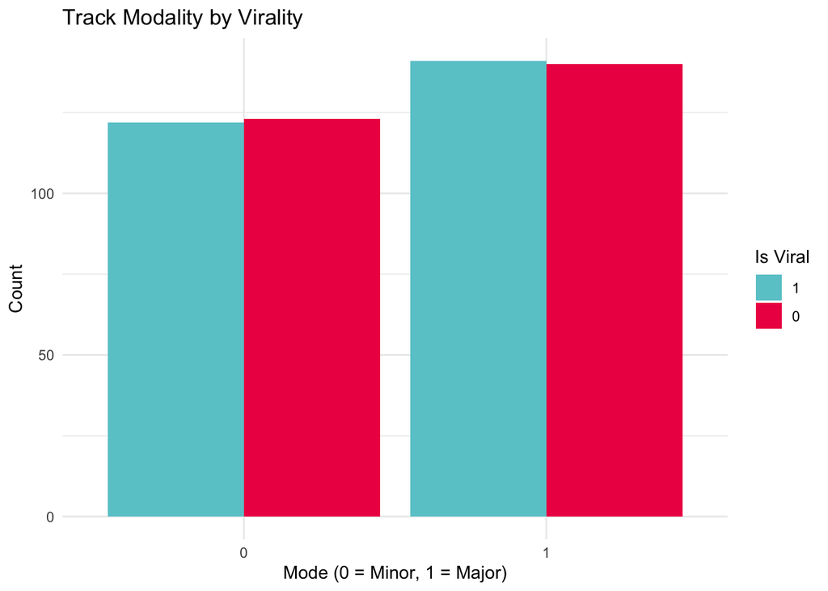

```r
# bar plot for mode
ggplot(music_df, aes(x = mode, fill = is_viral)) +
  geom_bar(position = "dodge") +
  scale_fill_manual(values = c("0" = "#EE1D52", "1" = "#69C9D0")) +
  labs(title = "Track Modality by Virality",
       x = "Mode (0 = Minor, 1 = Major)",
       y = "Count",
       fill = "Is Viral") +
  theme_minimal()
```

This grouped bar chart compares the count of major and minor key songs between the two groups. It helps to determine if a specific mode is overwhelmingly favored by the TikTok algorithm or user base.

From a machine learning perspective, this tells me that mode might have low “Variable Importance.” This determination comes from the fact that in this scenario, it doesn’t help distinguish a viral song from a regular popular song. As a result, the model will likely rely more heavily on continuous features like danceability or energy to make accurate predictions.

## Predictor Correlation

Before building the models, it is important to check for multicollinearity. This ensures that the predictor variables aren’t too highly correlated with each other. If two variables provide nearly identical information, it can make it difficult for the model to determine the individual impact of each feature, potentially leading to less stable results.”

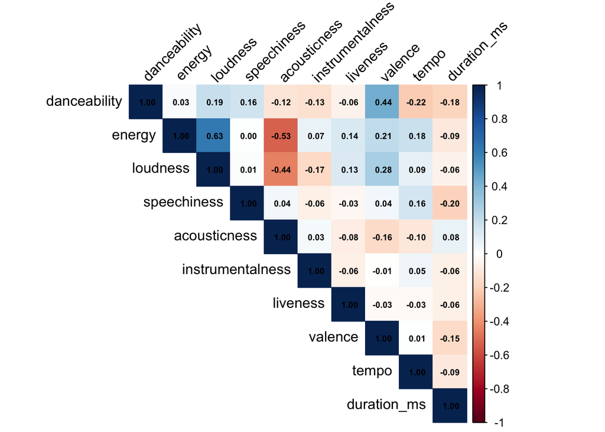

```r
library(corrplot)

# isolate only numeric continuous variables for correlation matrix
numeric_vars <- music_df %>%
  select(danceability, energy, loudness, speechiness, acousticness,
         instrumentalness, liveness, valence, tempo, duration_ms)

# calculate correlation matrix
cor_matrix <- cor(numeric_vars)

corrplot(cor_matrix, method = "color", type = "upper",
         tl.col = "black", tl.srt = 45, addCoef.col = "black", number.cex = 0.6)
```

# Data Splitting and Resampling

Before building the machine learning models, I need to split `music_df` into a training set and a testing set. Following best practices, the plan is to look 70% of the data and allocate it to training set to ensure the models have enough examples to learn from, and reserve the remaining 30% for final testing. To explain, the training set (70%) will be what’s observed to learn which features (like high energy or danceability) usually lead to a song going viral. The testing set (30%) will be stashed until the end for when a good formula for virality has been established and will then be used to predict the outcome for these songs to see how accurate it really is.

Since I want to ensure that the proportion of viral to non-viral tracks remains completely balanced in both sets, I plan to stratify this split based on the outcome variable, `is_viral`. In other words, I plan to ensure that there is an even representation of both groups.

```r
# set seed for reproducibility
set.seed(2026)

# create initial 70/30 split, stratified on target variable
music_split <- initial_split(music_df, prop = 0.70, strata = is_viral)

# extract training and testing sets
music_train <- training(music_split)
music_test <- testing(music_split)

dim(music_train)
```

```
## [1] 368  16
```

```r
dim(music_test)
```

```
## [1] 158  16
```

To prevent overfitting and properly tune the model hyperparameters later on, I will need to set up cross-validation on the training data. To do this, I will create 5 folds, again ensuring that stratification is applied on is_viral so each fold contains a representative sample of my classes.

```r
# create 5-fold cross-validation sets from training data
music_folds <- vfold_cv(music_train, v = 5, strata = is_viral)
```

## Model Recipe

With the data successfully split, I need to construct a recipe that tells the models how to handle the specific variables in my dataset.

My dataset contains identifying columns (track_name and artists) that are not acoustic features and should not be used as predictors. I will update their roles so they are retained in the dataset for identification but ignored by the algorithms. Furthermore, many machine learning models require continuous variables to be centered and scaled, and categorical variables to be transformed into numeric formats.

```r
music_recipe <- recipe(is_viral ~ ., data = music_train) %>%
  # keep track_name and artists in data, do not use as predictors
  update_role(track_name, artists, new_role = "ID") %>%
  # dummy encode categorical predictors (mode and key)
  step_dummy(all_nominal_predictors()) %>%
  # center and scale continuous acoustic features
  step_normalize(all_numeric_predictors())

music_recipe
```

```
## ── Recipe ──────────────────────────────────────────────────────────────────────
```

```
## ── Inputs
```

```
## Number of variables by role
```

```
## outcome:    1
## predictor: 13
## ID:         2
```

```
## ── Operations
```

```
## • Dummy variables from: all_nominal_predictors()
```

```
## • Centering and scaling for: all_numeric_predictors()
```

This recipe ensures that my outcome variable (is_viral) is properly modeled as a function of the acoustic predictor variables, while dummy-encoding, or turning categorical words (like “Major” or “Minor”) into numbers (0 or 1) so the computer can understand them, my categorical features and standardizing the numeric features so no single variable dominates the model due to its raw scale.

# Model Building and Tuning

With my data prepared and recipe established, I will fit four distinct machine learning models to identify the best predictor of TikTok virality. The models include a baseline Logistic Regression, an Elastic Net model, a Pruned Decision Tree, and a Random Forest.

### 1. Model Specifications

First, I specify the computational engines and identify which hyperparameters need to be tuned via cross-validation to optimize their performance.

```r
# 1. standard logistic regression (baseline)
log_spec <- logistic_reg() %>%
  set_engine("glm") %>%
  set_mode("classification")

# 2. elastic net regression (tuning penalty and mixture)
elastic_spec <- logistic_reg(penalty = tune(), mixture = tune()) %>%
  set_engine("glmnet") %>%
  set_mode("classification")

# 3. pruned decision tree (tuning cost complexity)
tree_spec <- decision_tree(cost_complexity = tune()) %>%
  set_engine("rpart") %>%
  set_mode("classification")

# 4. random forest (tuning mtry, trees, and min_n)
rf_spec <- rand_forest(mtry = tune(), trees = tune(), min_n = tune()) %>%
  set_engine("ranger") %>%
  set_mode("classification")
```

### 2. Workflows

Next, I plan to bundle my pre-processing music_recipe with each of my model specifications into workflows. This ensures the data is processed identically across all four model types.

```r
log_wf <- workflow() %>% add_recipe(music_recipe) %>% add_model(log_spec)
elastic_wf <- workflow() %>% add_recipe(music_recipe) %>% add_model(elastic_spec)
tree_wf <- workflow() %>% add_recipe(music_recipe) %>% add_model(tree_spec)
rf_wf <- workflow() %>% add_recipe(music_recipe) %>% add_model(rf_spec)
```

### 3. Hyperparameter Tuning Grids

For the models that require tuning, I need to establish grids with reasonable ranges for the hyperparameters to test across the cross-validation folds.

```r
# elastic net grid
elastic_grid <- grid_regular(penalty(), mixture(), levels = 5)

# decision tree grid
tree_grid <- grid_regular(cost_complexity(), levels = 10)

# random forest grid
# mtry ranges from 1 to number of predictors (13 acoustic features)
rf_grid <- grid_regular(mtry(range = c(1, 13)),
                        trees(range = c(200, 600)),
                        min_n(range = c(5, 20)),
                        levels = 3)
```

### 4. Fitting and Tuning the Models

Now, it’s time to fit the models using the 5-fold cross-validation sets (music_folds). For the models with tunable parameters, I use tune_grid() to find the optimal combinations.

```r
# fit logistic regression
log_fit <- fit_resamples(log_wf,
                         resamples = music_folds,
                         metrics = metric_set(roc_auc, accuracy))

# tune elastic net
elastic_tune <- tune_grid(elastic_wf,
                          resamples = music_folds,
                          grid = elastic_grid,
                          metrics = metric_set(roc_auc, accuracy))
# tune decision tree
tree_tune <- tune_grid(tree_wf,
                       resamples = music_folds,
                       grid = tree_grid,
                       metrics = metric_set(roc_auc, accuracy))

# tune random forest
rf_tune <- tune_grid(rf_wf,
                     resamples = music_folds,
                     grid = rf_grid,
                     metrics = metric_set(roc_auc, accuracy))
```

### 5. Evaluating Tuning Results

To understand how the hyperparameters affected model performance, I’d like to visualize the results of our tuning process using the autoplot() function.

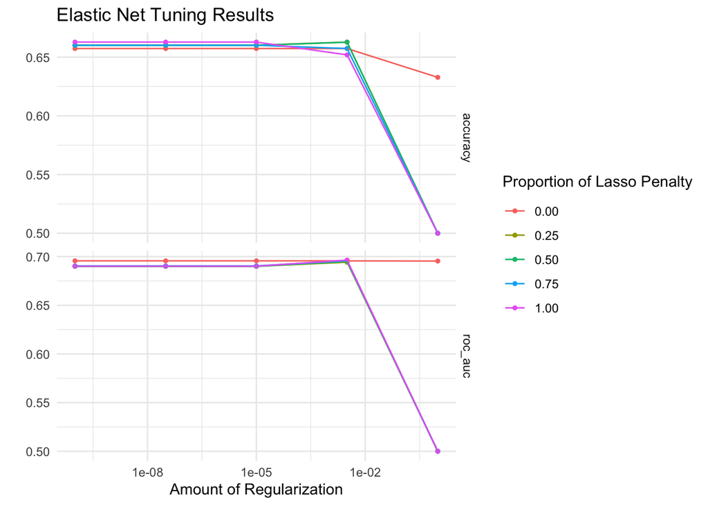

```r
# plot elastic net results
autoplot(elastic_tune) +
  theme_minimal() +
  labs(title = "Elastic Net Tuning Results")
```

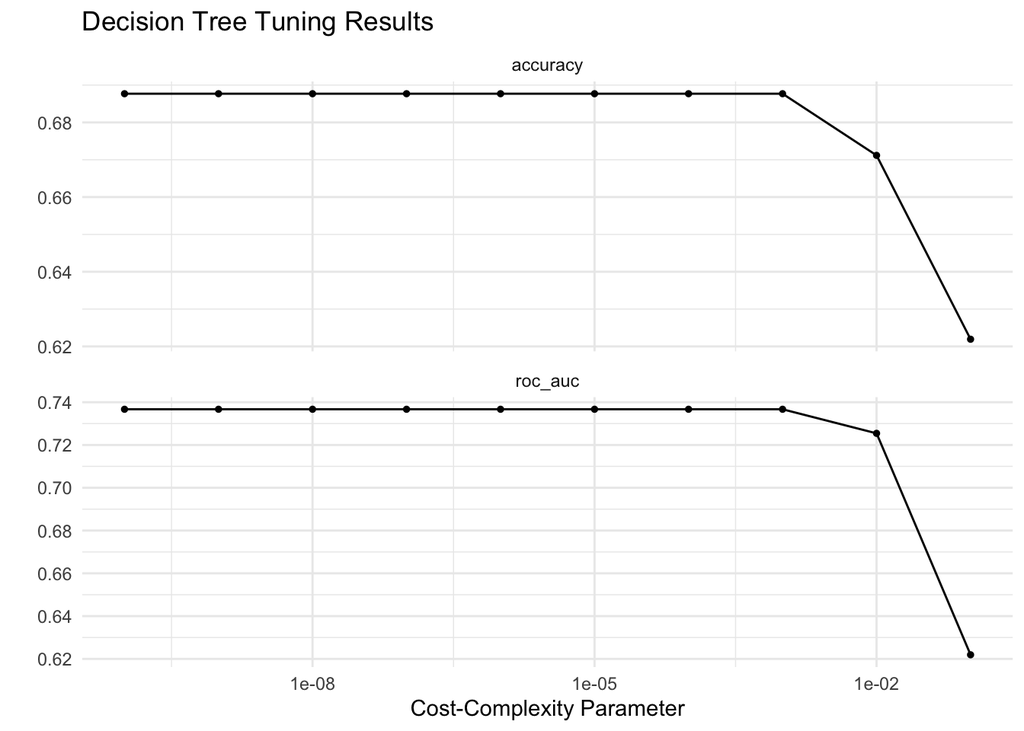

```r
# plot decision tree results
autoplot(tree_tune) +
  theme_minimal() +
  labs(title = "Decision Tree Tuning Results")
```

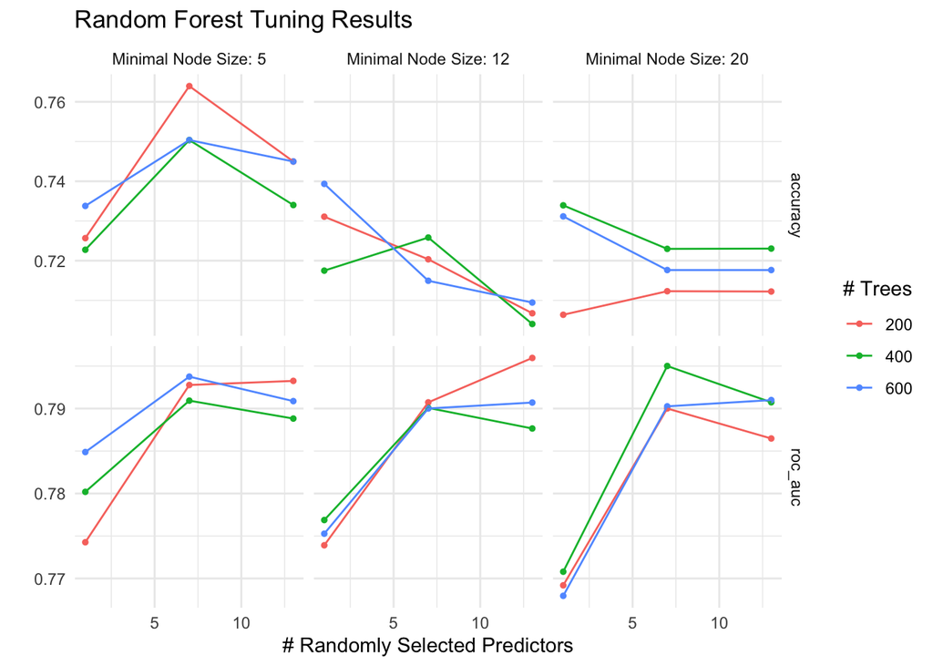

```r
# plot random forest results
autoplot(rf_tune) +
  theme_minimal() +
  labs(title = "Random Forest Tuning Results")
```

As seen in the plots above, different combinations of hyperparameters yield varying Area Under the ROC Curve (ROC AUC) and Accuracy scores. By visualizing these grids, we can identify which specific tuning parameters resulted in the highest predictive performance for each model before we finalize them.

In doing so, it is observed that in the Random Forest plot, performance (ROC AUC) increases as mtry is increased, but eventually levels off. This tells that the model needs a certain amount of complexity to “understand” TikTok trends, but adding too much doesn’t necessarily make it better, just slower.

For the Elastic Net, it shows which combination of “simplifying” the model (Penalty) and “selecting” variables (Mixture) works best. If the line dips sharply, that means that the model is becoming too simple and is “underfitting” essentially. In other words, it’s ignoring important musical features that it needs to tell the two groups apart.

Lastly, for the Decision Tree plot, looking at cost complexity reveals exactly when the tree gets too “choppy.” A very low cost complexity means a massive tree that might just be memorizing the Spotify songs. As the cost increases, the tree gets smaller. This plot determines the exact point where the tree is small enough to be useful but large enough to be accurate.

# Model Comparison and Selection

Now that I have fitted and tuned tje four models, the next step is to compare their performance to select the best one for my final predictions. I will use the Area Under the ROC Curve (ROC AUC) as my primary metric for comparison, as it is a strong measure for classification tasks.

```r
# extract best ROC AUC score for each model
log_metrics <- collect_metrics(log_fit) %>%
  filter(.metric == "roc_auc") %>%
  mutate(model = "Logistic Regression") %>%
  select(model, mean)

elastic_metrics <- show_best(elastic_tune, metric = "roc_auc") %>%
  slice(1) %>%
  mutate(model = "Elastic Net") %>%
  select(model, mean)

tree_metrics <- show_best(tree_tune, metric = "roc_auc") %>%
  slice(1) %>%
  mutate(model = "Decision Tree") %>%
  select(model, mean)

rf_metrics <- show_best(rf_tune, metric = "roc_auc") %>%
  slice(1) %>%
  mutate(model = "Random Forest") %>%
  select(model, mean)

# combine and display results
model_comparisons <- bind_rows(log_metrics, elastic_metrics, tree_metrics, rf_metrics) %>%
  arrange(desc(mean))

model_comparisons
```

| model | mean |
| --- | --- |
| Random Forest | 0.7959570 |
| Decision Tree | 0.7366943 |
| Elastic Net | 0.6964307 |
| Logistic Regression | 0.6883957 |

# Final Model Evaluation

For the Final Model Evaluation, I will now apply the best Random Forest model to the music_test data that was set aside at the very beginning of this project. It is crucial to only use the best model on the testing set to get an unbiased estimate of its real-world performance.

```r
# select best hyperparameters for the random forest
best_rf_params <- select_best(rf_tune, metric = "roc_auc")

# finalize the workflow with these optimal parameters
final_rf_wf <- finalize_workflow(rf_wf, best_rf_params)

# fit the final model to the testing data
final_fit <- last_fit(final_rf_wf, split = music_split)

# report the testing error (Accuracy and ROC AUC)
collect_metrics(final_fit)
```

| .metric | .estimator | .estimate | .config |
| --- | --- | --- | --- |
| accuracy | binary | 0.7848101 | Preprocessor1_Model1 |
| roc_auc | binary | 0.8784650 | Preprocessor1_Model1 |
| brier_class | binary | 0.1498738 | Preprocessor1_Model1 |

The metrics above display the testing error of the final model. To visualize this predictive performance, I’d like to generate a final ROC curve.

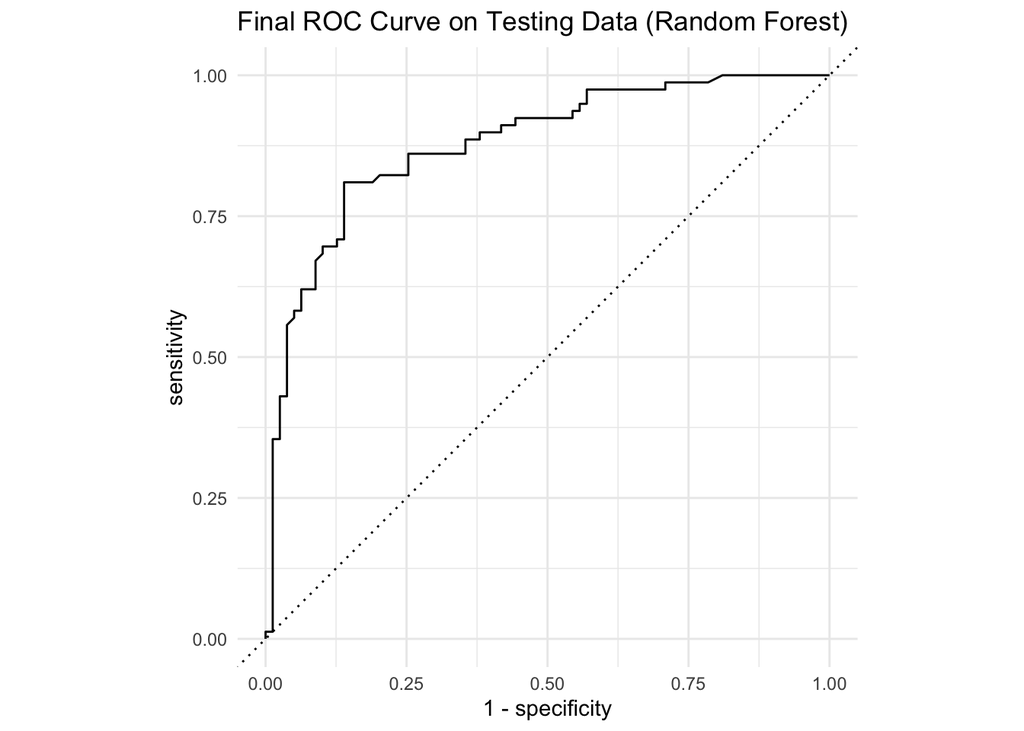

```r
# plot the final ROC curve
collect_predictions(final_fit) %>%
  roc_curve(is_viral, .pred_1) %>%
  autoplot() +
  theme_minimal() +
  labs(title = "Final ROC Curve on Testing Data (Random Forest)")
```

The ROC curve visualizes the trade-off between the true positive rate and the false positive rate. The closer the curve pushes toward the top-left corner, the better my model is at distinguishing between viral TikTok tracks and general Spotify tracks.

In this, the dotted diagonal line represents a model with no predictive power. The fact that the solid curve arches high above this line shows that the model has successfully identified distinct acoustic patterns that separate TikTok virality from general Spotify popularity.

The curve climbs very quickly on the left side designating that the model can identify a large majority of “Viral” tracks (True Positives) while only misclassifying a very small percentage of Spotify tracks as viral (False Positives).

Lastly, in terms of predictive confidence, since the curve pushes so close to the top-left corner, I can determine with confidence that the Area Under the Curve (AUC) is high. In simpler terms, this means if I picked one random viral song and one random Spotify song, the model would correctly identify which is which more often than not.

# Conclusion

While the balanced dataset provided enough signal to achieve these results, the relatively small sample size of 526 total tracks (263 per class) suggests that these findings are a preliminary exploration. Future research with larger datasets could further validate if these acoustic trends remain consistent across a wider variety of genres and years. Furthermore, it would be highly beneficial to incorporate non-acoustic features into the models, such as artist follower counts, marketing budget estimates, or the time of year a song is released, as algorithmic virality is likely influenced by a combination of sonic profile and social context.

Finally, it is important to explicitly acknowledge a significant limitation regarding measurement error within this analysis. TikTok virality is heavily driven by “remix culture,” where audio is frequently sped-up, slowed-down, or heavily altered by users. The acoustic features pulled from the Spotify API represent the canonical studio versions of these tracks. Therefore, our results must be interpreted carefully as they highlight the predictive contribution and associations of the original studio track’s sonic profile, rather than the exact audio manipulation that may have been used in the viral TikTok video clips themselves.

Ultimately, this study highlights that while digital trends may seem random, they are often anchored by specific acoustic foundations; by understanding these patterns, we gain a clearer picture of the sonic DNA that defines the tracks we choose to create to, share, and dance to every day.

[figure not shown]